# CRIM 595 Hot Spots Project

Hannah Dawson

7/1/2023

# Packages

These were the packages used to help uncover call clusters:

```r
library(tidyverse)
library(leaflet)
library(sf)
library(tigris)
```

# Data

These lines of code extract the City of Fairfax Police Departments Calls for Service and input necessary geographic data:

```r
id.calls <- "1gRoL7lZlwm7sreA5F9WbPoH5su4n4iGS"
calls.temp <- read.csv(sprintf("https://docs.google.com/uc?id=%s&export=download", id.calls))

fairfax.roads <- roads("VA", "Fairfax city")
fairfax.city <- county_subdivisions("VA", "Fairfax city")
```

## Data formatting

These lines of code merge all of the above data into one table and correctly format it according to each calls date

```r
calls.temp$date <- as.Date(calls.temp$date)
calls.temp$dow <- weekdays(calls.temp$date)
calls.temp$month <- substr(calls.temp$date, 6, 7)
calls.full <- subset(calls.temp, !is.na(calls.temp$lat))
```

# Calculating and differentiating calls

This block of code helps to separate calls by their respective types, count them by their year, and reveal the most common types of calls in descending order

```r
calls.year <- calls.full %>%
  group_by(year) %>%
  summarise(count = n()) %>%
  mutate(PCT = round(count/sum(count)*100,2))


calls.type <- calls.full %>%
  group_by(type) %>%
  summarise(count = n()) %>%
  mutate(PCT = round(count/sum(count)*100,2))


calls.type <- calls.type[order(-calls.type$count),]
diffs <- diff(calls.type$PCT)
diffs <- c(0, diffs)
calls.type$diff <- diffs
```

# Subseting the data

Here, I chose to specifically analyze 911 hang up calls and family fight calls together with the theory that many of these calls may be intertwined with and correlate to one another

```r
calls <- subset(calls.full, calls.full$type == '911 HANG-UP' | calls.full$type == 'FAMILY FIGHT')
```

# Analysis

### Hotspot and Coldspot activity throughout the week

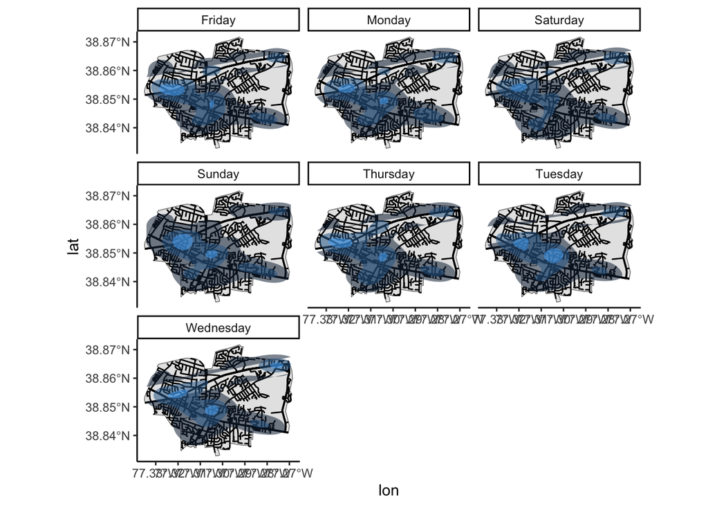

```r
ggplot() +
  geom_sf(data = fairfax.city) +
  geom_sf(data = fairfax.roads) +
  stat_density2d(aes(x = lon, y = lat, fill = ..level.., alpha = 0.01),
                 size = 0.01, bins = 4, data = calls, geom = "polygon") +
  theme_classic() +
  theme(legend.position = "none") +
  facet_wrap(~ dow, nrow = 3)
```

In analyzing how calls for service, specifically 911 hang up calls and family fight calls, cluster across time on a day-by-day basis, the set of maps above reveals the general hot spots for these calls relevant to the days of the week. On average, 1-3 hot spots for 911 hang up calls and family fight calls are prevalent each day with Wednesday being the most prominent of the 7 days and Saturday being the least. The two biggest and most consistent hot spots for these calls are located in the western and downtown regions of Fairfax City. The majority of calls deriving out of the Western end are fixated on the intersection of Lee Jackson Memorial Highway, Fairfax Blvd, and Lee Highway. The majority of the calls originating out of the downtown region are at the intersection of University Drive to Layton Hall, and Layton Hall to Old Lee Highway. Southeast to this intersection is a neighborhood with 136+ calls, mainly concentrated on Layton Hill Drive. Along with these two main hot spots, another pops up as a focal point on Wednesdays at the north eastern end of Fairfax City located on the Arlington Blvd strip itself. Right after the roundabout headed eastward on Arlington Blvd, there is a heavy concentration of these calls mainly occurring on Wednesdays.

Despite the fluctuation in number and size of hotspots to occur on a day to day basis of these calls, the cold spots remain consistent. There are four main cold spots for these specific calls located in the north west, north, east, and south regions of Fairfax City. In regard to the north end, Shiloh Street Park stretching east toward Stafford Drive Park and the area above are considered a cold spot. For the northwest region, Cainsborough Ct stretching east towards Assembly Drive and the area above are considered to be a cold spot. In the Eastern region, the intersections of Arlington Blvd and Picket Road, downwards towards the intersection of Main Street and Picket Road, and westwards towards Ashby Pond and north towards Old Lee Hills are considered to be a cold spot. Finally, in the Southern region, the majority of the region South of Main Street down towards Burke Station Road, Robert’s Road, and Chain Bridge Road are cold spots.

In predicting the future hot spots to occur on a day to day basis, I would predict for the western and downtown regions to remain the central focal points of these calls on an every day basis. I would predict for the majority of calls to consistently derive out of the western region, in line with the current trends. I would also predict Wednesdays to accumulate the most spread out calls, with many deriving out of the Northeastern region which is different, and an added hotspot compared to the other 6 days. As it goes for cold spots, I predict the listed cold spots to remain the same as they have not had much variation throughout the past sixteen years.

### Hotspot and Coldspot activity by months of the year

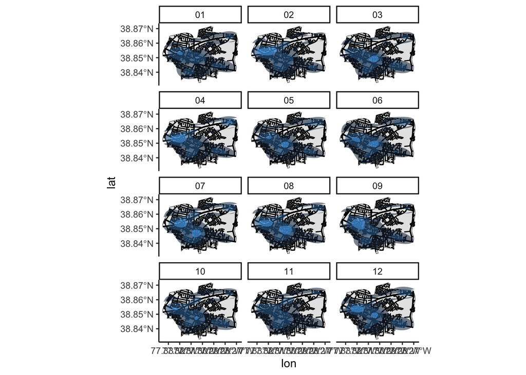

```r
ggplot() +
  geom_sf(data = fairfax.city) +
  geom_sf(data = fairfax.roads) +
  stat_density2d(aes(x = lon, y = lat, fill = ..level.., alpha = 0.01),
                 size = 0.01, bins = 4, data = calls, geom = "polygon") +
  theme_classic() +
  theme(legend.position = "none") +
  facet_wrap(~ month, nrow = 4)
```

Similar to the previous section, the maps above reveal the variation in size and number of hot spots for these calls to occur on a month-by-month basis. Analysis of these maps reveal 1-3 hot spots to be prevalent each month, with July and December accruing the most (3) and March, September, and November accruing the least (1). The most consistent and typically largest hotspot is in the Western part of the region at the intersection of Lee Jackson Memorial Highway, Fairfax Blvd, and Lee Highway. The second most common and largest hotspot is in the downtown region at the intersection of University Drive to Layton Hall, and Layton Hall to Old Lee Highway. These are the two most consistent hot spots both occurring in January, February, May, June, July, August, October, and December. Though much smaller in size, the next biggest hotspot occurs in the North Eastern region of Fairfax County located on the eastern part of the Arlington Blvd strip. This is one of the central hot spots in only April and July. Then occurring in December only, a very minor hot spot pops up just north of the eastern strip of Main Street towards Bradwater Street. Interestingly, although the Western region typically has the largest and most frequent hotspot throughout these months, it is not even considered a hot spot in March and November.

In line with the previous section, the cold spots remain the same with very little variation throughout the months. There are four main cold spots; located in the north west, north, east, and south most regions. There does however appear to be some minor fluctuation in the northern regions cold spot with some gray area sneaking into the Stafford Drive Park community. One noticeable variation that occurs while analyzing cold spots by each month is that the mid north regions gray area (presumably mild spots) fluctuates each month from the north west to the north east, slightly changing the hot and cold spot patterns on Fairfax Blvd and the communities just above and below it.

As it goes for predicting future hot spots on a month by month basis, I predict for the western region hotspot to remain the most consistent and largest hot spot followed by the downtown region in line with the data. I predict February, April, and September to be months that have calls most heavily deriving out of the western region. I as well believe that overtime the hot spot in the downtown area will become larger in size and more consistent each month, more so reflecting the western regions hot spot as it does in various months (August for example). For future cold spots, I believe the patterns will continue to be the same leaving the north western, northern, eastern, and southern regions of Fairfax City as cold spots with little predictable variation throughout the months.

### Hotspot and Coldspot activity by hour

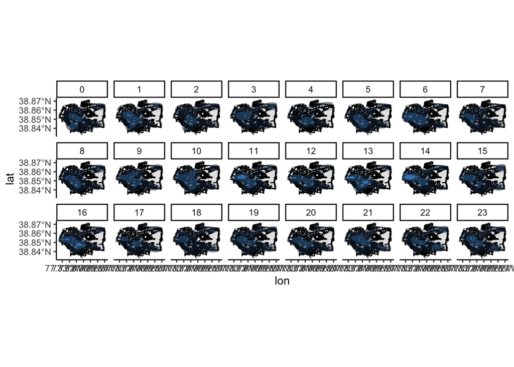

```r
ggplot() +
  geom_sf(data = fairfax.city) +
  geom_sf(data = fairfax.roads) +
  stat_density2d(aes(x = lon, y = lat, fill = ..level.., alpha = 0.01),
                 size = 0.01, bins = 4, data = calls, geom = "polygon") +
  theme_classic() +
  theme(legend.position = "none") +
  facet_wrap(~ hour, nrow = 3)
```

In analyzing how these clusters vary on an hour-by-hour basis, the maps above reveal 911 hang up calls and family fight calls to actually most commonly occur between the hours of 11am-4pm. These maps also make very clear how much significantly bigger the western regions hot spot is in comparison to the other mentioned three as the bright blue spots (the greatest of the hot spots) only occurs in the west aside from the two times it also occurs in the downtown region. These bright blue spots occur in the western region eight respective times; at 1am, 6am, 11am, 12pm, 1pm, 2pm, 4pm, and 11pm. Six out of these eight spots are located at the intersection of Lee Jackson Memorial Highway, Fairfax Blvd, and Lee Highway, while the other two are located on Fairfax Blvd alone at 1am and 11pm. As it goes for the downtown region, only two bright blue hot spots occurred, one at 1pm and the other at 4pm. Both spots covering the intersecting areas of University Drive to Layton Hall, and Layton Hall to Old Lee Highway.

Similar to the previous two analyses, the cold spots are for the most of it unchanging and the same as reported above. The cold spots are the north western, northern, eastern, and southern regions of Fairfax City. As seen above, what changes hour-by-hour are the gray spots which presumably indicate that calls have picked up at those hours in those locations, but that they do not amount to being considered hot spot locations. What mostly varies is the gray area that is present on Fairfax Blvd and Arlington Blvd in the northern half of Fairfax City, making the north western, northern, and eastern cold spots more condensed or widened dependent on the hour.

In terms of predicting future hot spots, I would predict that most calls are going to be concentrated in the western region hot spot. Specifically at the intersection of Lee Jackson Memorial Highway, Fairfax Blvd, and Lee Highway. I also predict that the majority of calls will occur mid day rather than early morning or early evening, but that calls will begin to pick up again at the later hours between 11pm-1am to a lesser extent. For cold spots, I predict that the northern cold spot will remain the least unaffected by gray areas of increased calls in comparison to the other three cold spots. Aside from 6pm-11pm and 2am, the north cold spot (stretching from Shiloh Street to Stafford Drive Park and above) goes unchanged. The north west, east, and south regions however do have variation throughout the hours. That said, I’d predict for these cold spots to remain unchanged but for the north west, east, and south cold spots to have a bit of variation, causing them to be condensed or widened throughout the day.

### Concluding thoughts

This interactive map displayed below helped me take an in-depth look at these hot and cold spots by pinpointing the street and road names in all of Fairfax City. First glance at it from afar reveals 1,788+ calls to have occurred in the northwest hot spot area 1,533+ to have occurred in the downtown hot spot area, 881+ to have occurred in the southeast hot spot area, and 576+ to have occurred in the northeast hot spot area.

```r
leaflet(calls) %>%
  addProviderTiles("CartoDB.DarkMatter") %>%
  addMarkers(lng = ~lon, lat = ~lat,
             popup = paste(
               "Call Type: ", calls$type, "<br>",
               "Date:", calls$date),
             clusterOptions = markerClusterOptions()) %>%
  addPolygons(data = fairfax.city)
```

[interactive chart not shown]